# Practical Machine Learning Course Project

Ilya Krasnikov

15 Jun 2017

# Introduction

#### Background

Using devices such as Jawbone Up, Nike FuelBand, and Fitbit it is now possible to collect a large amount of data about personal activity relatively inexpensively. These type of devices are part of the quantified self movement - a group of enthusiasts who take measurements about themselves regularly to improve their health, to find patterns in their behavior, or because they are tech geeks. One thing that people regularly do is quantify how much of a particular activity they do, but they rarely quantify how well they do it. In this project, your goal will be to use data from accelerometers on the belt, forearm, arm, and dumbell of 6 participants. They were asked to perform barbell lifts correctly and incorrectly in 5 different ways. More information is available from the website here: http://groupware.les.inf.puc-rio.br/har (see the section on the Weight Lifting Exercise Dataset).

#### Data

The training data for this project are available here: https://d396qusza40orc.cloudfront.net/predmachlearn/pml-training.csv

The test data are available here: https://d396qusza40orc.cloudfront.net/predmachlearn/pml-testing.csv

The data for this project come from this source: http://groupware.les.inf.puc-rio.br/har. If you use the document you create for this class for any purpose please cite them as they have been very generous in allowing their data to be used for this kind of assignment.

#### What you should submit

The goal of your project is to predict the manner in which they did the exercise. This is the “classe” variable in the training set. You may use any of the other variables to predict with. You should create a report describing how you built your model, how you used cross validation, what you think the expected out of sample error is, and why you made the choices you did. You will also use your prediction model to predict 20 different test cases.

*Peer Review Portion* Your submission should consist of a link to a Github repo with your R markdown and compiled HTML file describing your analysis. Please constrain the text of the writeup to < 2000 words and the number of figures to be less than 5. It will make it easier for the graders if you submit a repo with a gh-pages branch so the HTML page can be viewed online (and you always want to make it easy on graders :-).

*Course Project Prediction Quiz Portion* Apply your machine learning algorithm to the 20 test cases available in the test data above and submit your predictions in appropriate format to the Course Project Prediction Quiz for automated grading.

# 1. Loading data

Loading data into two datasets **train** and **test**:

```r
library(data.table)

rm(list=ls(all=TRUE))   ## clear worksace
gc()                    ## garbage collector
```

```
##          used (Mb) gc trigger (Mb) max used (Mb)
## Ncells 387750 20.8     750400 40.1   592000 31.7
## Vcells 588255  4.5    1308461 10.0   792884  6.1
```

```r
# Load CSV files
train <- read.csv("pml-training.csv", sep=",", na.strings = c("NA","#DIV/0!", ""))
test <- read.csv("pml-testing.csv", sep=",", na.strings = c("NA","#DIV/0!", ""))

dim(train)
```

```
## [1] 19622   160
```

The training data has 19622 observations and 160 features

# 2. Preprocessing

```r
# Delete columns with all missing values
train <- train[,colSums(is.na(train)) == 0]
test <- test[,colSums(is.na(test)) == 0]
```

Some variables are irrelevant to our current project: *user_name*, *raw_timestamp_part_1*, *raw_timestamp_part_*, *cvtd_timestamp*, *new_window*, and *num_window* (columns 1 to 7). Remove these variables:

```r
train <- train[,-c(1:7)]
test <- test[,-c(1:7)]

dim(train)
```

```
## [1] 19622    53
```

```r
dim(test)
```

```
## [1] 20 53
```

# 3. Model training and results

## 3.1 Partitioning the training data set to allow cross-validation

In order to perform cross-validation, the original training dataset splits into 2 new datasets: **dtrain** (60%) and **dtest** (40%). Use random subsampling without replacement from *caret* library. The function *set.seed()* allows generate same random values for each run and code reproducibility.

```r
library(caret)
set.seed(42)

subsamples <- createDataPartition(y=train$classe, p=0.6, list=FALSE)
dtrain <- train[subsamples, ]
dtest <- train[-subsamples, ]

dim(dtrain)
```

```
## [1] 11776    53
```

```r
dim(dtest)
```

```
## [1] 7846   53
```

The variable “classe” contains 5 levels: A, B, C, D and E. Let’s see the frequency of each levels in the training data set.

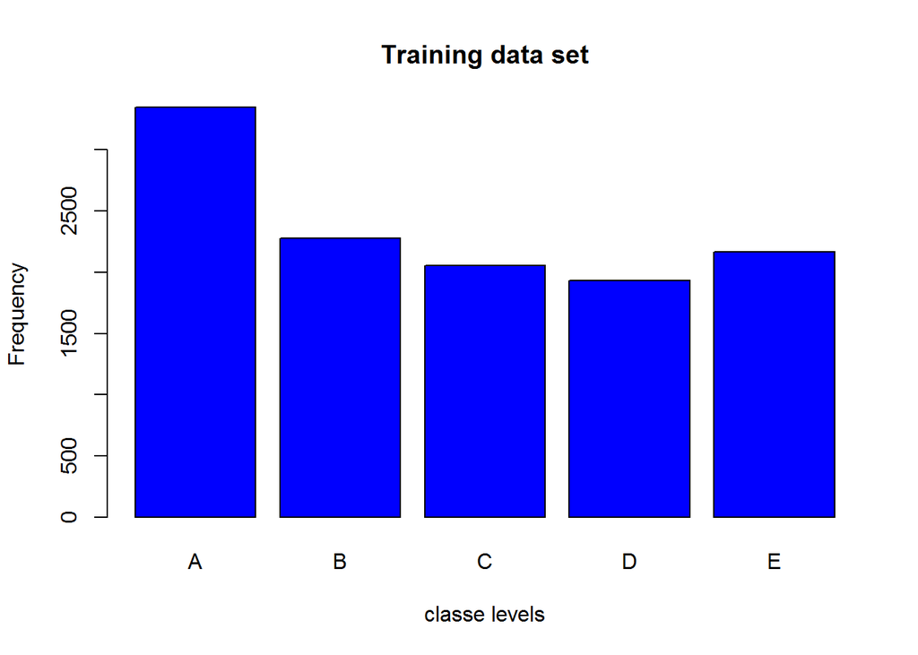

```r
plot(dtrain$classe, col="blue", main="Training data set", xlab="classe levels", ylab="Frequency")
```

#### Prediction model Decision Tree

```r
library(rpart)
```

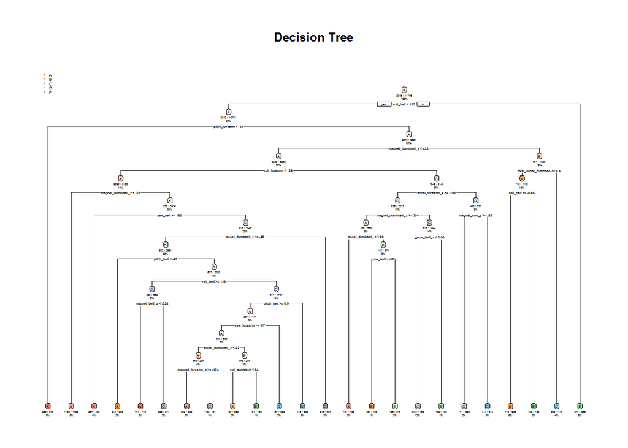

```r
library(rpart.plot)
modelDT <- rpart(classe ~ ., data=dtrain, method="class")

predictionDT <- predict(modelDT, dtest, type = "class")

# Plot of the tree
rpart.plot(modelDT, main="Decision Tree", extra=102, under=TRUE, faclen=0)
```

```r
# Test results
confusionMatrix(predictionDT, dtest$classe)
```

```
## Confusion Matrix and Statistics
##
##           Reference
## Prediction    A    B    C    D    E
##          A 2033  303   28  133   53
##          B   60  801   58   59  114
##          C   45  301 1178  142  167
##          D   78  103  103  879  116
##          E   16   10    1   73  992
##
## Overall Statistics
##
##                Accuracy : 0.7498
##                  95% CI : (0.7401, 0.7594)
##     No Information Rate : 0.2845
##     P-Value [Acc > NIR] : < 2.2e-16
##
##                   Kappa : 0.6823
##  Mcnemar's Test P-Value : < 2.2e-16
##
## Statistics by Class:
##
##                      Class: A Class: B Class: C Class: D Class: E
## Sensitivity            0.9108   0.5277   0.8611   0.6835   0.6879
## Specificity            0.9079   0.9540   0.8989   0.9390   0.9844
## Pos Pred Value         0.7973   0.7335   0.6427   0.6873   0.9084
## Neg Pred Value         0.9624   0.8938   0.9684   0.9380   0.9334
## Prevalence             0.2845   0.1935   0.1744   0.1639   0.1838
## Detection Rate         0.2591   0.1021   0.1501   0.1120   0.1264
## Detection Prevalence   0.3250   0.1392   0.2336   0.1630   0.1392
## Balanced Accuracy      0.9094   0.7408   0.8800   0.8113   0.8362
```

#### Prediction model Random Forest

```r
library(randomForest)
modelRF <- randomForest(classe ~. , data=dtrain, method="class")

predictionRF <- predict(modelRF, dtest, type = "class")

# Test results
confusionMatrix(predictionRF, dtest$classe)
```

```
## Confusion Matrix and Statistics
##
##           Reference
## Prediction    A    B    C    D    E
##          A 2231    7    0    0    0
##          B    1 1510   11    0    0
##          C    0    1 1353   17    0
##          D    0    0    4 1268    8
##          E    0    0    0    1 1434
##
## Overall Statistics
##
##                Accuracy : 0.9936
##                  95% CI : (0.9916, 0.9953)
##     No Information Rate : 0.2845
##     P-Value [Acc > NIR] : < 2.2e-16
##
##                   Kappa : 0.9919
##  Mcnemar's Test P-Value : NA
##
## Statistics by Class:
##
##                      Class: A Class: B Class: C Class: D Class: E
## Sensitivity            0.9996   0.9947   0.9890   0.9860   0.9945
## Specificity            0.9988   0.9981   0.9972   0.9982   0.9998
## Pos Pred Value         0.9969   0.9921   0.9869   0.9906   0.9993
## Neg Pred Value         0.9998   0.9987   0.9977   0.9973   0.9988
## Prevalence             0.2845   0.1935   0.1744   0.1639   0.1838
## Detection Rate         0.2843   0.1925   0.1724   0.1616   0.1828
## Detection Prevalence   0.2852   0.1940   0.1747   0.1631   0.1829
## Balanced Accuracy      0.9992   0.9964   0.9931   0.9921   0.9971
```

## 3.3 Prediction for Test dataset

```r
predictionTest <- predict(modelRF, test)
predictionTest
```

```
##  1  2  3  4  5  6  7  8  9 10 11 12 13 14 15 16 17 18 19 20
##  B  A  B  A  A  E  D  B  A  A  B  C  B  A  E  E  A  B  B  B
## Levels: A B C D E
```

Write files for submission

```r
pml_write_files = function(x){
  n = length(x)
  for(i in 1:n){
    filename = paste0("problem_id_",i,".txt")
    write.table(x[i],file=filename,quote=FALSE,row.names=FALSE,col.names=FALSE)
  }
}

pml_write_files(predictionTest)
```